# Week 12 | Chi-Squared

# Day 1

## Chi Squared Analysis Example

```r
#View(Titanic)
#?Titanic
```

Lets see if there was a relationship between passenger survival and ticket class.

```r
table(TitanicSurvival$passengerClass, TitanicSurvival$survived)
```

```
##
##        no yes
##   1st 123 200
##   2nd 158 119
##   3rd 528 181
```

Lets see if there was a relationship between passenger survival and gender.

```r
table(TitanicSurvival$sex, TitanicSurvival$survived)
```

```
##
##           no yes
##   female 127 339
##   male   682 161
```

### how c() can be used in Chi-squared Analysis

Bascially, you bind c() lists together into a matrix.

Look up rbind & cbind. They turn c() lists into a matrix. rbind turns each list and turns it into a row. cbind does the same but turns them into columns.

```r
fruit <- rbind(Apples=c(Good = 80, Bruised = 20, Rotten = 15),
               Oranges=c(Good = 75, Bruised = 25, Rotten = 10)
               )
fruit
```

```
##         Good Bruised Rotten
## Apples    80      20     15
## Oranges   75      25     10
```

```r
fruit <- cbind(Apples=c(Good = 80, Bruised = 20, Rotten = 15),
               Oranges=c(Good = 75, Bruised = 25, Rotten = 10)
               )
fruit
```

```
##         Apples Oranges
## Good        80      75
## Bruised     20      25
## Rotten      15      10
```

If you need to flip the matrix, just use the t() function.

```r
t(fruit)
```

```
##         Good Bruised Rotten
## Apples    80      20     15
## Oranges   75      25     10
```

### how to graphically summarise the data

Use a barplot.

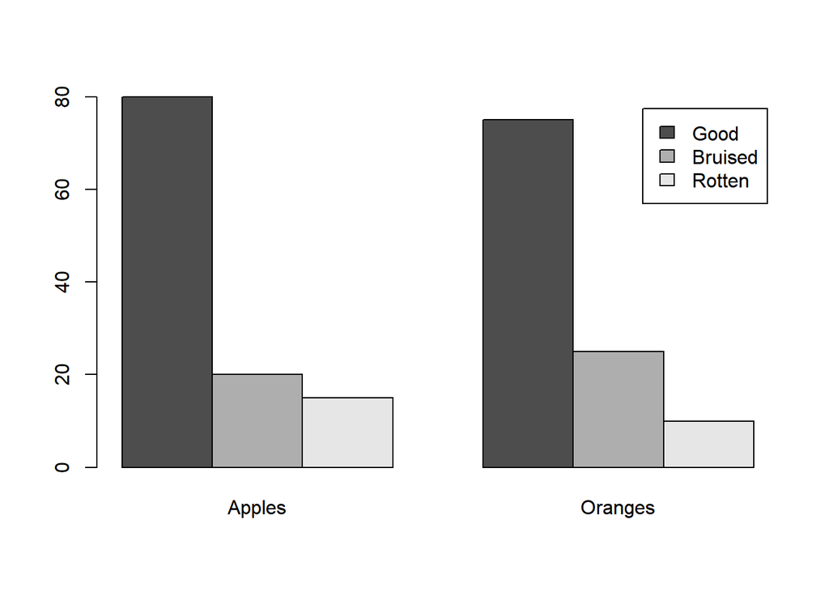

```r
barplot(fruit, beside = TRUE, legend.text = TRUE)
```

Is type of fruit connected to it’s condition?

```r
chisq.test(fruit)
```

```
##
##  Pearson's Chi-squared test
##
## data:  fruit
## X-squared = 1.6065, df = 2, p-value = 0.4479
```

# Day 2

## In class activity

Load the Data/GSS2012.csv file. NOTE: link to the original data is at http://sda.berkeley.edu/sdaweb/analysis/?dataset=gss12 and is from the 2012 Topical Surveys

```r
library(readr)
GSS2012 <- read_delim("../Data/GSS2012.csv",
                      "\t", escape_double = FALSE, trim_ws = TRUE)
names(GSS2012) # This shows the names of the columns
```

```
##   [1] "year"          "id"            "wtss"          "vpsu"
##   [5] "vstrat"        "RES2008"       "RES2010"       "isco88"
##   [9] "spisco88"      "paisco88"      "maisco88"      "1-Mar"
##  [13] "2-Mar"         "3-Mar"         "4-Mar"         "5-Mar"
##  [17] "6-Mar"         "7-Mar"         "8-Mar"         "11-Mar"
##  [21] "12-Mar"        "13-Mar"        "14-Mar"        "abany"
##  [25] "abdefect"      "abhlth"        "abnomore"      "abpoor"
##  [29] "abrape"        "absingle"      "accntsci"      "accptoth"
##  [33] "acqntsex"      "actupset"      "adults"        "advfront"
##  [37] "affrmact"      "age"           "aged"          "agekdbrn"
##  [41] "ARCHITCT"      "arrest"        "astrolgy"      "astrosci"
##  [45] "attend"        "away1"         "away11"        "away12"
##  [49] "away2"         "away3"         "away4"         "away5"
##  [53] "away6"         "away7"         "away8"         "babies"
##  [57] "ballot"        "balneg"        "balpos"        "barate"
```

[output cut: 190 more lines]

Pick any two columns you are interested in (as long as it isn’t the “id” column). You’ll probably have no idea what the columns represent for now, that’s okay. Just pick two of the names.

Say you picked the columns: nameOfColumn1 and nameOfColumn2 then run the codes:

> table(GSS2012$nameOfColumn1)

> table(GSS2012$nameOfColumn2)

> table(GSS2012$nameOfColumn1, GSS2012$nameOfColumn2)

This gives you some insight about how many of each response there are in the data.

```r
library(mosaic)

matrix.a <- GSS2012 %>% select(RATETONE, JOKESWK) %>% filter(RATETONE != 0 & JOKESWK !=0)

table(matrix.a$RATETONE)
```

```
##
##   1   2   3   4   5   6   7   8   9  10  99
## 307 309 153  76  45  25  33  28   7  10 186
```

```r
table(matrix.a$JOKESWK)
```

```
##
##   1   2   3   4   8   9
##  30  95 180 821  22  31
```

```r
table(matrix.a$RATETONE, matrix.a$JOKESWK)
```

```
##
##        1   2   3   4   8   9
##   1    8  33  43 209   3  11
##   2    9  28  57 202   6   7
##   3    3   6  31 111   1   1
##   4    2   8   9  55   1   1
##   5    1   6   2  35   0   1
##   6    1   2   4  16   1   1
##   7    2   0   4  25   1   1
##   8    1   5   4  16   2   0
##   9    0   0   0   7   0   0
##   10   1   0   0   9   0   0
##   99   2   7  26 136   7   8
```

```r
table(matrix.a$JOKESWK, matrix.a$RATETONE)
```

```
##
##       1   2   3   4   5   6   7   8   9  10  99
##   1   8   9   3   2   1   1   2   1   0   1   2
##   2  33  28   6   8   6   2   0   5   0   0   7
##   3  43  57  31   9   2   4   4   4   0   0  26
##   4 209 202 111  55  35  16  25  16   7   9 136
##   8   3   6   1   1   0   1   1   2   0   0   7
##   9  11   7   1   1   1   1   1   0   0   0   8
```

Turn the three table(…) commands that you just ran into barplots in R. (Open the “Graphical Summaries” page of the Statistics-Notebook if you need help remembering how to do this.)

Show your barplots to your peers, a TA, or the teacher to ensure that you have made them each correctly.

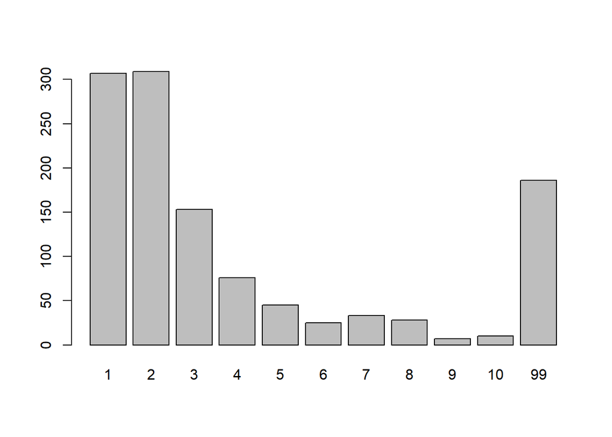

```r
barplot(table(matrix.a$RATETONE))
```

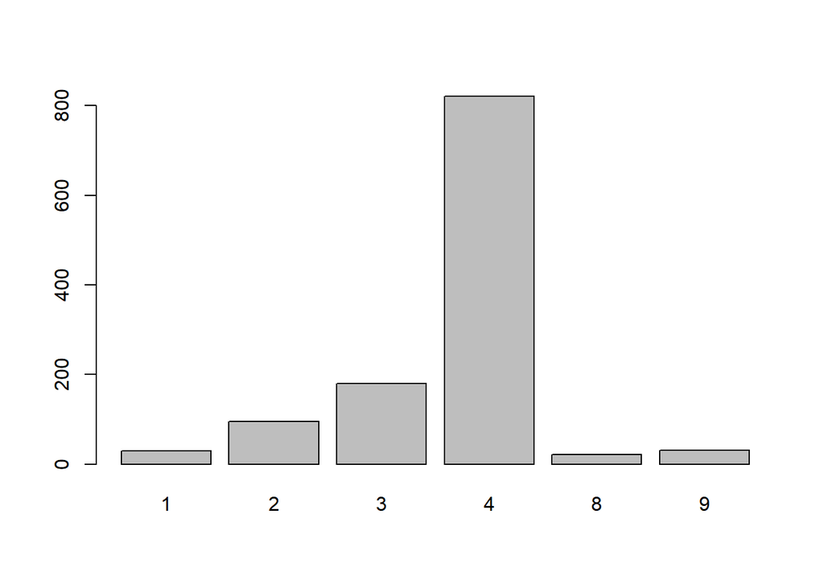

```r
barplot(table(matrix.a$JOKESWK))
```

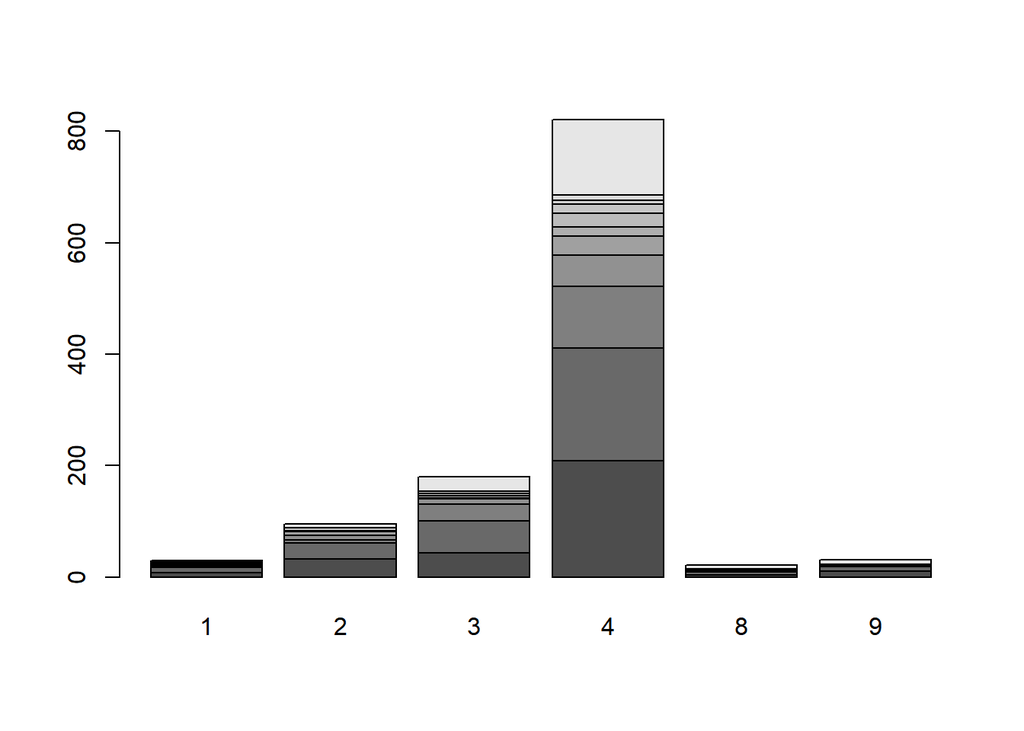

```r
barplot(table(matrix.a$RATETONE, matrix.a$JOKESWK))
```

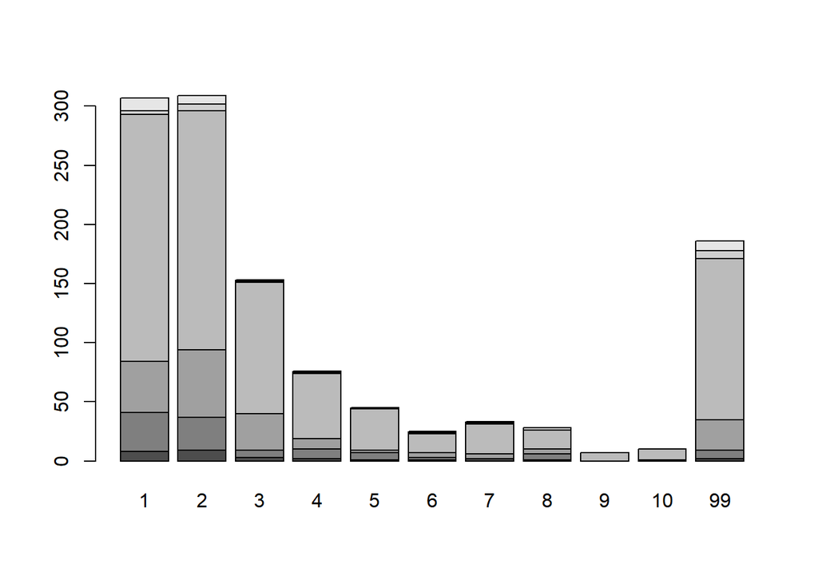

```r
barplot(table(matrix.a$JOKESWK, matrix.a$RATETONE))
```

Run a chi-squared test on your two columns to see if they are independent or associated with each other.

```r
toneXjokes <- table(matrix.a$JOKESWK, matrix.a$RATETONE)

chiresults.toneXjokes <- chisq.test(toneXjokes)
chiresults.toneXjokes
```

```
##
##  Pearson's Chi-squared test
##
## data:  toneXjokes
## X-squared = 62.511, df = 50, p-value = 0.1102
```

Check the requirements of your chi-squared test. Are the results of the test valid?

```r
chiresults.toneXjokes$expected
```

```
##
##              1          2          3         4          5          6          7
##   1   7.811705   7.862595   3.893130  1.933842  1.1450382  0.6361323  0.8396947
##   2  24.737065  24.898219  12.328244  6.123834  3.6259542  2.0144190  2.6590331
##   3  46.870229  47.175573  23.358779 11.603053  6.8702290  3.8167939  5.0381679
##   4 213.780322 215.173028 106.541985 52.922816 31.3358779 17.4088210 22.9796438
##   8   5.728584   5.765903   2.854962  1.418151  0.8396947  0.4664970  0.6157761
##   9   8.072095   8.124682   4.022901  1.998304  1.1832061  0.6573367  0.8676845
##
##              8         9        10         99
##   1  0.7124682 0.1781170 0.2544529   4.732824
##   2  2.2561493 0.5640373 0.8057676  14.987277
##   3  4.2748092 1.0687023 1.5267176  28.396947
##   4 19.4978796 4.8744699 6.9635284 129.521628
##   8  0.5224767 0.1306192 0.1865988   3.470738
##   9  0.7362171 0.1840543 0.2629347   4.890585
```

Suppose you called your chi-squared test, mychisq in R. Then run

mychisq$residuals

Then, open your Statistics-Notebook to the “Explanation” tab of the “Chi Squared Tests” page. Scroll down until you find the part on “Interpretation” and discuss with your group how “Pearson Residuals” are used to interpret the results of a chi-squared test.

If your group is confused about the Pearson Residuals, ask your teacher for help.

```r
chiresults.toneXjokes$residuals
```

```
##
##               1           2           3           4           5           6
##   1  0.06736995  0.40563181 -0.45265271  0.04757407 -0.13554151  0.45621521
##   2  1.66134654  0.62162291 -1.80232298  0.75815782  1.24674586 -0.01015922
##   3 -0.56531190  1.43037088  1.58102128 -0.76418223 -1.85807729  0.09377576
##   4 -0.32694396 -0.89803177  0.43189797  0.28553116  0.65455932 -0.33765342
##   8 -1.14002304  0.09749034 -1.09782932 -0.35113319 -0.91634855  0.78111036
##   9  1.03053762 -0.39457225 -1.50714220 -0.70620684 -0.16842624  0.42264293
##
##               7           8           9          10          99
##   1  1.26622708  0.34064589 -0.42203915  1.47798949 -1.25617902
##   2 -1.63065419  1.82673927 -0.75102418 -0.89764559 -2.06318130
##   3 -0.46252083 -0.13291465 -1.03378058 -1.23560413 -0.44980319
##   4  0.42145994 -0.79215681  0.96272792  0.77172697  0.56923907
##   8  0.48963560  2.04409413 -0.36141274 -0.43197085  1.89440574
##   9  0.14204628 -0.85803096 -0.42901548 -0.51277158  1.40604182
```

Nicely done! You can use this for your Chi-squared analysis this week if you like.

# Skills Quiz

## Q1

Review the Notebook

## Q2

Refer to the Explanation file of your Chi Squared Tests page of your Statistics Notebook for the following questions.

### 1)

In the following table, the factor for the rows would be called $Class$ and the factor for the columns would be called $Survival$.

```
No  Yes
```

1st 122 203 2nd 167 118 3rd 528 178 Crew 673 212

### 2)

$H_0$ : The row variable and column variable are independent. $H_a$ : The row variable and column variable are associated.

The Ei in the χ2 test statistic formula are called the $expected$ counts and are obtained by multiplying the row total with the $column$ $total$ and dividing by the $total$ $total$. These values show us what values we would expect to observe if the null hypothesis was true. In other words, they provide the counts we would expect if the row variable and column variable were $independent$.

The χ2 test statistic can be assumed to follow a $\text{chi-squared distribution}$ with degrees of freedom p=($r - 1$)*(c−1).

The chi-squared distribution is a $parametric$ distribution because is has a single parameter known as the degrees of freedom, p.

Pearson $residuals$ are useful for interpreting the results of a chi-squared test when the $alternative$ hypothesis can be concluded to be the truth. They show a relative measurement of how much the $observed $ counts differ from the $expected$ counts.

## Q3

The following questions refer to the R Instructions and the HairEyeColor example of the Chi-squared Tests page.

Run the following code in R. (This data is fabricated to mimick reality, but is not actual data.)

```r
glasses <- cbind( Males = c(Glasses = 5, Contacts = 12, None = 18), Females = c(Glasses = 4, Contacts = 14, None = 22))

glasses
```

```
##          Males Females
## Glasses      5       4
## Contacts    12      14
## None        18      22
```

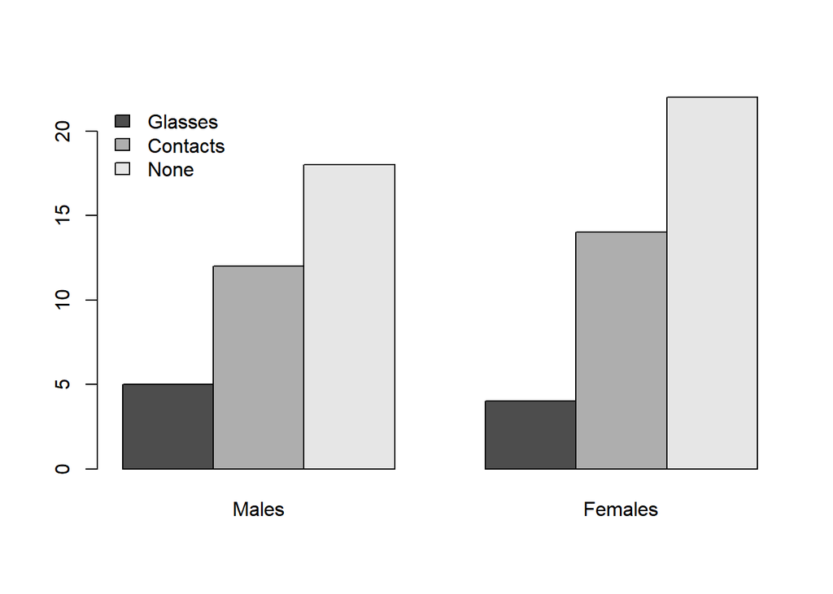

```r
barplot(glasses, beside=TRUE, legend.text=TRUE, args.legend=list(x = "topleft", bty="n"))
```

### 1)

Which of the following statements are correct interpretations of the bar plot that the above code generated in R?

answer:

The data shows that the most common result for either males or females is to not wear glasses or contacts. It also shows that the least common result for both genders is to wear glasses. In other words, the pattern for both genders is the same.

and

The gender of an individual does not seem to be associated with whether a person wears glasses, contacts, or no eye correction because the pattern of the bars is essentially the same for males and females.

### 2)

The correct null and alternative hypotheses for these data are

$H_0$ Corrective eye wearing and gender are independent $H_a$ Corrective eye wearing and gender are associated

### 3)

Run the following code in R to determine if a chi-squared test of independence is appropriate for the glasses data.

```r
chis.glasses <- chisq.test(glasses)
chis.glasses$expected
```

```
##             Males  Females
## Glasses   4.20000  4.80000
## Contacts 12.13333 13.86667
## None     18.66667 21.33333
```

Are the requirements for this test satisfied?

answer: Yes, the requirements are met because the average of the expected counts is greater than 5 and all expected counts are greater than 1, even though some expected counts are less than 5.

### 4)

Run the following code in R to view the results of your test.

```r
chis.glasses
```

```
##
##  Pearson's Chi-squared test
##
## data:  glasses
## X-squared = 0.3331, df = 2, p-value = 0.8466
```

χ2= 0.3331

degrees of freedom = 2

p-value = 0.8466

### 5)

This confirms our original suspicion that we saw in the graphic. There is $insufficient$ evidence to conclude that corrective eye wearing and gender are $associated$. We will continue to assume the null hypothesis that whether someone wears glasses, contacts, or no corrective eye wear is $independent$ of their gender.

Since we failed to reject the null there is no interpretation to make for these data so we are not interested in the Pearson Residuals. However, so that you get the opportunity to see what the Pearson Residuals look like when we fail to reject, run the following code in R and notice that none of the residuals stand out as being exceptionally large in magnitude. This is always the case when we fail to reject the null hypothesis in a chi-squared test of independence.

> chis.glasses$residuals

## Q4

### 1)

These questions allow you to check your understanding of how to properly perform a Chi-squared Test of Independence in R.

Asia has become a major competitor with the U.S and Western Europe in education. The following table presents the counts of university degrees awarded to students in engineering and science (natural and social sciences) for the three regions.

```
    Region
```

Field United States Western Europe Asia Engineering 61941 158931 280772 Natural Science 111158 140126 242879 Social Science 182166 116353 236018

The following code gets this data into R.

```r
education <- cbind( `United States` = c(Engineering = 61941, `Natural Science` = 111158, `Social Science` = 182166), `Western Europe` = c(Engineering = 158931, `Natural Science` = 140126, `Social Science` = 116353), Asia = c(280772, 242879, 236018))

education
```

```
##                 United States Western Europe   Asia
## Engineering             61941         158931 280772
## Natural Science        111158         140126 242879
## Social Science         182166         116353 236018
```

Are there any differences in the numbers of degrees awarded to each field for the different regions? In other words, are field and region associated? Or can we assume that all three countries are similar in their patterns of degrees being awarded?

The null and alternative hypotheses for this study are: $H_0$: Field and Region are independent $H_a$: Field and Region are associated

```r
FandR.chi <- chisq.test(education)

FandR.chi$expected
```

```
##                 United States Western Europe     Asia
## Engineering          116455.2       136170.6 249018.1
## Natural Science      114718.5       134139.9 245304.5
## Social Science       124091.2       145099.4 265346.3
```

```r
FandR.chi$residuals
```

```
##                 United States Western Europe       Asia
## Engineering        -159.74613       61.67899  63.632829
## Natural Science     -10.51231       16.34414  -4.897263
## Social Science      164.86059      -75.46591 -56.935221
```

```r
FandR.chi
```

```
##
##  Pearson's Chi-squared test
##
## data:  education
## X-squared = 69890, df = 4, p-value < 2.2e-16
```

### 2)

Create an appropriate graphic in R for this analysis. It should look like this:

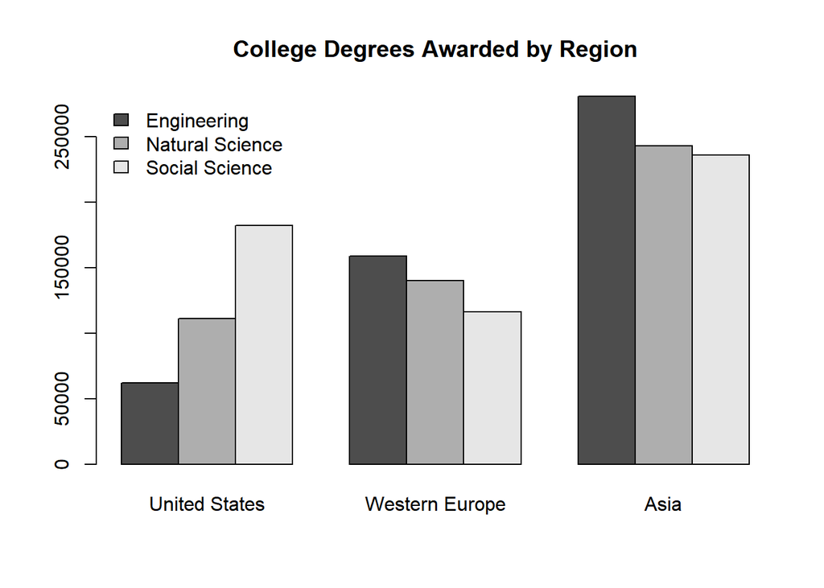

```r
barplot(cbind( `United States` = c(Engineering = 61941, `Natural Science` = 111158, `Social Science` = 182166), `Western Europe` = c(Engineering = 158931, `Natural Science` = 140126, `Social Science` = 116353), Asia = c(280772, 242879, 236018)),
        beside = TRUE,
        main = "College Degrees Awarded by Region",
        legend.text = TRUE,
        args.legend =
          list(x = "topleft",
               bty = "n")
        )
```

### 3)

Obtain the Pearson Residuals for this analysis. To check that you obtained them correctly, enter the residual for Engineering in Western Europe:

```r
FandR.chi$residuals
```

```
##                 United States Western Europe       Asia
## Engineering        -159.74613       61.67899  63.632829
## Natural Science     -10.51231       16.34414  -4.897263
## Social Science      164.86059      -75.46591 -56.935221
```

## Q5

This is a review question. It covers one of the topics we have previously studied this semester. It should help you review for the final exam.

Consider the InsectSprays dataset in R.

?InsectSprays

### 1)

Test the hypothesis that the mean number of bugs killed by insectisides A, B, C, D, E, and F are all the same against the alternative that at least one mean is different.

```r
insect <- table(InsectSprays$count, InsectSprays$spray)

Insect.chi <- chisq.test(insect)
Insect.chi
```

```
##
##  Pearson's Chi-squared test
##
## data:  insect
## X-squared = 185.86, df = 115, p-value = 3.19e-05
```

```r
Insect.chi$expected
```

```
##
##              A         B         C         D         E         F
##   0  0.3333333 0.3333333 0.3333333 0.3333333 0.3333333 0.3333333
##   1  1.0000000 1.0000000 1.0000000 1.0000000 1.0000000 1.0000000
##   2  0.6666667 0.6666667 0.6666667 0.6666667 0.6666667 0.6666667
##   3  1.3333333 1.3333333 1.3333333 1.3333333 1.3333333 1.3333333
##   4  0.6666667 0.6666667 0.6666667 0.6666667 0.6666667 0.6666667
##   5  1.1666667 1.1666667 1.1666667 1.1666667 1.1666667 1.1666667
##   6  0.5000000 0.5000000 0.5000000 0.5000000 0.5000000 0.5000000
##   7  0.5000000 0.5000000 0.5000000 0.5000000 0.5000000 0.5000000
##   9  0.1666667 0.1666667 0.1666667 0.1666667 0.1666667 0.1666667
##   10 0.5000000 0.5000000 0.5000000 0.5000000 0.5000000 0.5000000
##   11 0.5000000 0.5000000 0.5000000 0.5000000 0.5000000 0.5000000
##   12 0.3333333 0.3333333 0.3333333 0.3333333 0.3333333 0.3333333
##   13 0.6666667 0.6666667 0.6666667 0.6666667 0.6666667 0.6666667
##   14 0.6666667 0.6666667 0.6666667 0.6666667 0.6666667 0.6666667
##   15 0.3333333 0.3333333 0.3333333 0.3333333 0.3333333 0.3333333
##   16 0.3333333 0.3333333 0.3333333 0.3333333 0.3333333 0.3333333
##   17 0.6666667 0.6666667 0.6666667 0.6666667 0.6666667 0.6666667
##   19 0.1666667 0.1666667 0.1666667 0.1666667 0.1666667 0.1666667
##   20 0.3333333 0.3333333 0.3333333 0.3333333 0.3333333 0.3333333
##   21 0.3333333 0.3333333 0.3333333 0.3333333 0.3333333 0.3333333
##   22 0.1666667 0.1666667 0.1666667 0.1666667 0.1666667 0.1666667
##   23 0.1666667 0.1666667 0.1666667 0.1666667 0.1666667 0.1666667
##   24 0.1666667 0.1666667 0.1666667 0.1666667 0.1666667 0.1666667
##   26 0.3333333 0.3333333 0.3333333 0.3333333 0.3333333 0.3333333
```

```r
Insect.chi$residuals
```

```
##
##               A          B          C          D          E          F
##   0  -0.5773503 -0.5773503  2.8867513 -0.5773503 -0.5773503 -0.5773503
##   1  -1.0000000 -1.0000000  3.0000000 -1.0000000  1.0000000 -1.0000000
##   2  -0.8164966 -0.8164966  1.6329932  0.4082483  0.4082483 -0.8164966
##   3  -1.1547005 -1.1547005  0.5773503  0.5773503  2.3094011 -1.1547005
##   4  -0.8164966 -0.8164966  0.4082483  1.6329932  0.4082483 -0.8164966
##   5  -1.0801234 -1.0801234 -1.0801234  3.5489770  0.7715167 -1.0801234
##   6  -0.7071068 -0.7071068 -0.7071068  0.7071068  2.1213203 -0.7071068
##   7   0.7071068  0.7071068  0.7071068 -0.7071068 -0.7071068 -0.7071068
##   9  -0.4082483 -0.4082483 -0.4082483 -0.4082483 -0.4082483  2.0412415
##   10  2.1213203 -0.7071068 -0.7071068 -0.7071068 -0.7071068  0.7071068
##   11 -0.7071068  2.1213203 -0.7071068 -0.7071068 -0.7071068  0.7071068
##   12  1.1547005 -0.5773503 -0.5773503  1.1547005 -0.5773503 -0.5773503
##   13  0.4082483  0.4082483 -0.8164966 -0.8164966 -0.8164966  1.6329932
##   14  2.8577380  0.4082483 -0.8164966 -0.8164966 -0.8164966 -0.8164966
##   15 -0.5773503 -0.5773503 -0.5773503 -0.5773503 -0.5773503  2.8867513
##   16 -0.5773503  1.1547005 -0.5773503 -0.5773503 -0.5773503  1.1547005
##   17  0.4082483  2.8577380 -0.8164966 -0.8164966 -0.8164966 -0.8164966
##   19 -0.4082483  2.0412415 -0.4082483 -0.4082483 -0.4082483 -0.4082483
##   20  2.8867513 -0.5773503 -0.5773503 -0.5773503 -0.5773503 -0.5773503
##   21 -0.5773503  2.8867513 -0.5773503 -0.5773503 -0.5773503 -0.5773503
##   22 -0.4082483 -0.4082483 -0.4082483 -0.4082483 -0.4082483  2.0412415
##   23  2.0412415 -0.4082483 -0.4082483 -0.4082483 -0.4082483 -0.4082483
##   24 -0.4082483 -0.4082483 -0.4082483 -0.4082483 -0.4082483  2.0412415
##   26 -0.5773503 -0.5773503 -0.5773503 -0.5773503 -0.5773503  2.8867513
```

The p-value of the test is less than $.05$ showing that there is $sufficient$ evidence to conclude that $\text{at least one bug spray results in a different}$ average number of bugs per agricultural experimental unit than the other sprays.

Thus, we should not make any conclusion about these insect sprays until next week when we can use the non-parametric version of ANOVA called the “Kruskal-Wallis Test.” In other words, this test is inconclusive due to difficulties with the requirements not being satisfied.

# Assessment Quiz

## Q1

What type of statistical test would be appropriate for understanding how gender impacts the risk a person of a certain age has of having a heart attack?

Answer: Multiple Logistic Regression

We are trying to predict an outcome, whether or not the person will experience a heart attack, using their age and gender. Age is a quantitative measurement, gender is a qualitative measurement, and the response variable Y could be 1 for a heart attack and 0 for no heart attack. This is the perfect scenario of a multiple logistic regression.

## Q2

Which statistical method would be best suited for determining how the age and gender of an individual can predict their annual income, measured in thousands of dollars?

Answer: Multiple Linear Regression

The response variable of this scenario, annual income measured in thousands, is quantitative. Since we have a quantitative explanatory variable of age and a qualitative explanatory variable of gender, a multiple linear regression would be the best choice.

## Q3

Run the following codes in R:

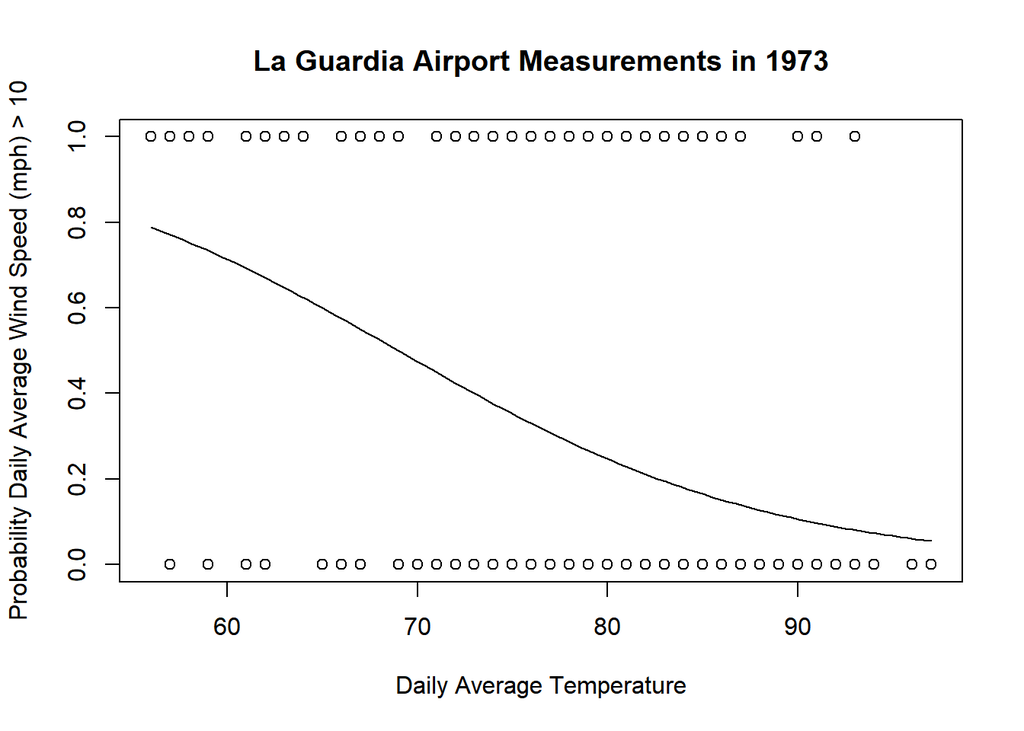

```r
plot((Wind > 10) ~ Temp, data=airquality, xlab="Daily Average Temperature", ylab="Probability Daily Average Wind Speed (mph) > 10", main="La Guardia Airport Measurements in 1973")

air.glm <- glm(Wind > 10 ~ Temp + as.factor(Month), data=airquality, family=binomial)

curve(exp(air.glm$coefficients[1]+air.glm$coefficients[2]*x)/(1 + exp(air.glm$coefficients[1] + air.glm$coefficients[2]*x)), add = TRUE)
```

During which month is there a significant change in the probability that the daily average wind speed will be greater than 10 mph, for all values of daily average temperature?

ANSWER: No change

```r
summary(glm(Wind > 10 ~ Temp + as.factor(Month), data=airquality, family=binomial))
```

```
##
## Call:
## glm(formula = Wind > 10 ~ Temp + as.factor(Month), family = binomial,
##     data = airquality)
##
## Deviance Residuals:
##     Min       1Q   Median       3Q      Max
## -1.7457  -0.9825  -0.6264   1.0925   1.8717
##
## Coefficients:
##                   Estimate Std. Error z value Pr(>|z|)
## (Intercept)        6.99664    1.92840   3.628 0.000285 ***
## Temp              -0.10140    0.02867  -3.537 0.000405 ***
## as.factor(Month)6  0.87217    0.65487   1.332 0.182919
## as.factor(Month)7  0.73891    0.74202   0.996 0.319348
## as.factor(Month)8  1.00550    0.73050   1.376 0.168682
## as.factor(Month)9  1.25238    0.64839   1.932 0.053418 .
## ---
## Signif. codes:  0 '***' 0.001 '**' 0.01 '*' 0.05 '.' 0.1 ' ' 1
##
## (Dispersion parameter for binomial family taken to be 1)
##
##     Null deviance: 211.57  on 152  degrees of freedom
## Residual deviance: 190.09  on 147  degrees of freedom
## AIC: 202.09
##
## Number of Fisher Scoring iterations: 4
```

```r
# look at the p-values. They are all greater than .05 so fail to reject the null.
```